# Foundations for statistical inference - Sampling distributions

# Exercise 7:

# Take a sample of size 15 from the population and calculate the proportion of people in this sample who

# think the work scientists do enhances their lives. Using this sample, what is your best point

# estimate of the population proportion of people who think the work scientists do enchances their lives?

```r
samp15 <- global_monitor %>%
  sample_n(15)

samp15 %>%
  count(scientist_work) %>%
  mutate(p15 = n /sum(n))
```

```
## # A tibble: 2 x 3
##   scientist_work      n   p15
##   <chr>           <int> <dbl>
## 1 Benefits           11 0.733
## 2 Doesn't benefit     4 0.267
```

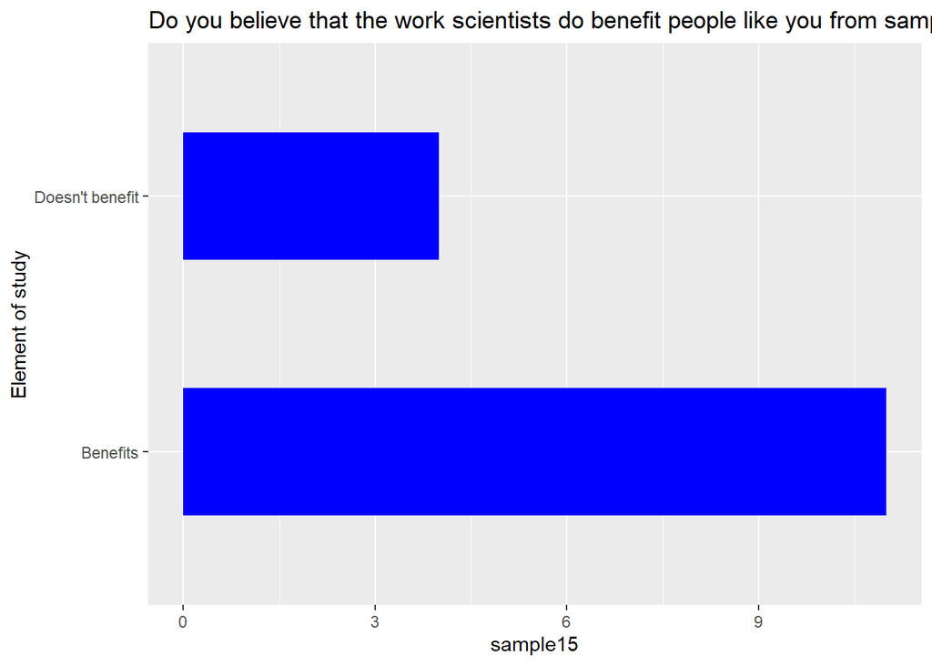

```r
ggplot(samp15, aes(x = scientist_work)) +
    geom_bar(position = position_dodge(), width = 0.5, fill = "blue" ) +
    coord_flip() +
    ggtitle("Do you believe that the work scientists do benefit people like you from sample 0f 15?") +
    xlab("Element of study") + ylab("sample15")
```

Exercise 8: # Since you have access to the population, simulate the sampling distribution of proportion of those who # think the work scientists do enchances their lives for samples of size 15 by taking 2000 samples from # the population of size 15 and computing 2000 sample proportions. Store these proportions in as sample_props15. # Plot the data, then describe the shape of this sampling distribution. Based on this sampling distribution, # what would you guess the true proportion of those who think the work scientists do enchances their lives to be? # Finally, calculate and report the population proportion.

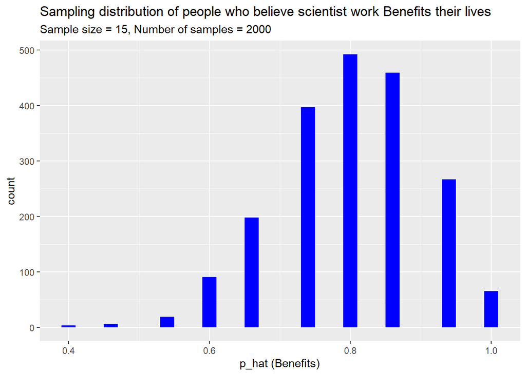

```r
sample_props15 <- global_monitor %>%
                    rep_sample_n(size = 15, reps = 2000, replace = TRUE) %>%
                    count(scientist_work) %>%
                    mutate(p_hat = n /sum(n)) %>%
                    filter(scientist_work == "Benefits")

# ggplot(data = sample_props_small, aes(x = p_hat)) +
#   geom_histogram(binwidth = 0.02)

ggplot(data = sample_props15 , aes(x = p_hat)) +
  geom_histogram(binwidth = 0.02, fill = "blue") +
  labs(
    x = "p_hat (Benefits)",
    title = "Sampling distribution of people who believe scientist work Benefits their lives",
    subtitle = "Sample size = 15, Number of samples = 2000"
  )
```

```r
summary(sample_props15)
```

```
##    replicate      scientist_work           n             p_hat
##  Min.   :   1.0   Length:2000        Min.   : 6.00   Min.   :0.4000
##  1st Qu.: 500.8   Class :character   1st Qu.:11.00   1st Qu.:0.7333
##  Median :1000.5   Mode  :character   Median :12.00   Median :0.8000
##  Mean   :1000.5                      Mean   :11.99   Mean   :0.7997
##  3rd Qu.:1500.2                      3rd Qu.:13.00   3rd Qu.:0.8667
##  Max.   :2000.0                      Max.   :15.00   Max.   :1.0000
```

# Exercise 9:

# Change your sample size from 15 to 150, then compute the sampling distribution using the same method as above,

# and store these proportions in a new object called sample_props150. Describe the shape of this sampling

# distribution and compare it to the sampling distribution for a sample size of 15. Based on this sampling

# distribution, what would you guess to be the true proportion of those who think the work scientists do

# enchances their lives?

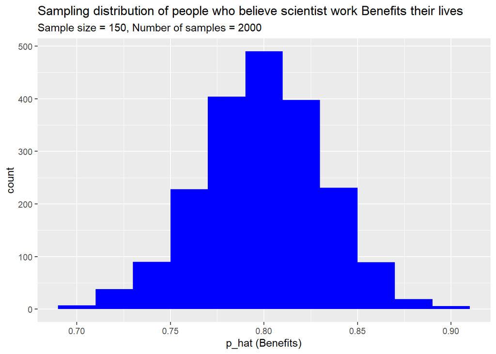

```r
sample_props150 <- global_monitor %>%
                    rep_sample_n(size = 150, reps = 2000, replace = TRUE) %>%
                    count(scientist_work) %>%
                    mutate(p_hat = n /sum(n)) %>%
                    filter(scientist_work == "Benefits")

# ggplot(data = sample_props_small, aes(x = p_hat)) +
#   geom_histogram(binwidth = 0.02)

ggplot(data = sample_props150 , aes(x = p_hat)) +
  geom_histogram(binwidth = 0.02, fill = "blue") +
  labs(
    x = "p_hat (Benefits)",
    title = "Sampling distribution of people who believe scientist work Benefits their lives",
    subtitle = "Sample size = 150, Number of samples = 2000"
  )
```

```r
summary(sample_props150)
```

```
##    replicate      scientist_work           n             p_hat
##  Min.   :   1.0   Length:2000        Min.   :104.0   Min.   :0.6933
##  1st Qu.: 500.8   Class :character   1st Qu.:117.0   1st Qu.:0.7800
##  Median :1000.5   Mode  :character   Median :120.0   Median :0.8000
##  Mean   :1000.5                      Mean   :119.9   Mean   :0.7991
##  3rd Qu.:1500.2                      3rd Qu.:123.0   3rd Qu.:0.8200
##  Max.   :2000.0                      Max.   :136.0   Max.   :0.9067
```

# Exercise 10:

# Of the sampling distributions from 2 and 3, which has a smaller spread? If you’re concerned

# with making estimates that are more often close to the true value, would you prefer a sampling

# distribution with a large or small spread?

```r
# Pratice to take a sampling distribution with a small spread.
# This also mean getting a sample of large size.
```